# Week 6 - Rmarkdown Assignment

Surenther

2024-10-05

# Iris Dataset Analysis

```r
#Assign Iris dataset
iris_data <- iris
```

## Average Sepal Length by Species

```r
# Load the dplyr package
library(dplyr,warn.conflicts = FALSE)

# Group the iris dataset by species and calculate the average sepal length
average_sepal_length <- iris_data %>%
  group_by(Species) %>%
  summarise(avg_sepal_length = mean(Sepal.Length))

# View the results
knitr::kable(average_sepal_length, caption='Average Sepal Length.')
```

Average Sepal Length.

| Species | avg_sepal_length |
| --- | --- |
| setosa | 5.006 |
| versicolor | 5.936 |
| virginica | 6.588 |

## Visualizations

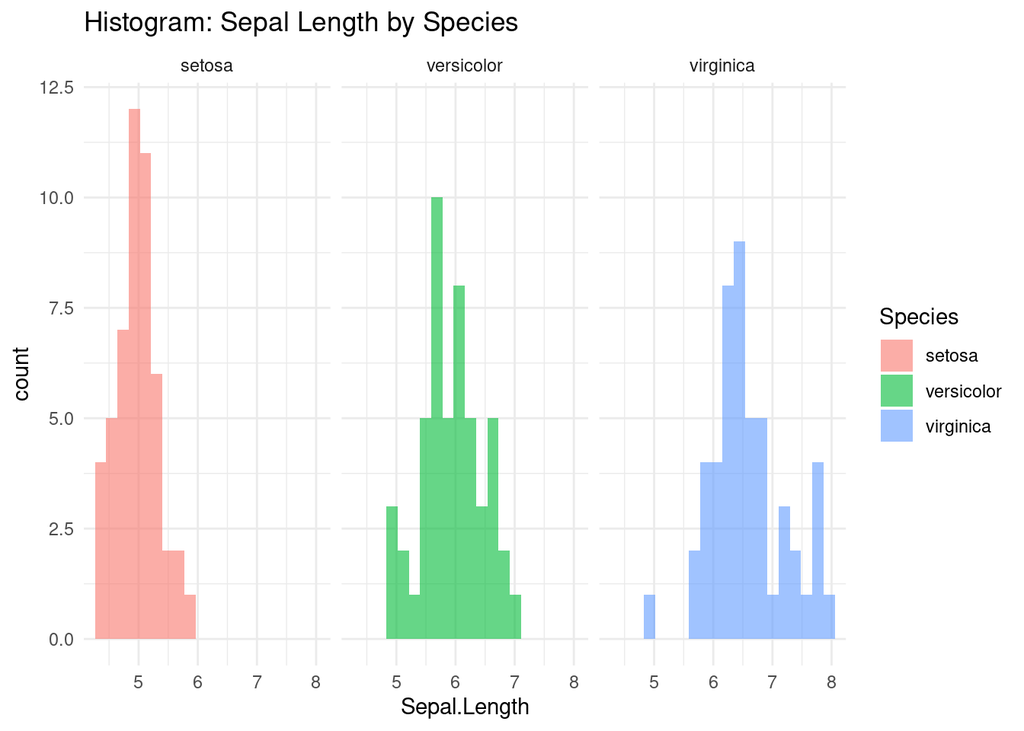

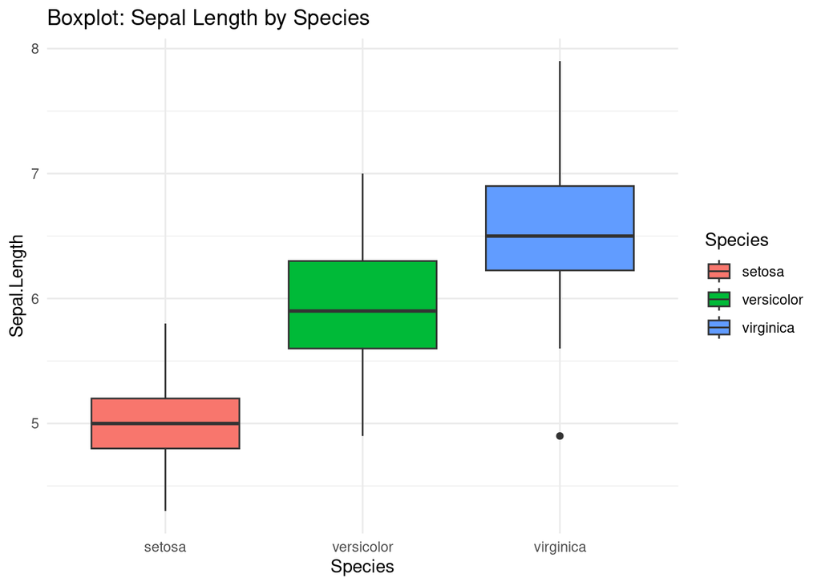

```r
# Histogram and Box plot for Sepal Length
  ggplot(iris, aes(x = Sepal.Length, fill = Species)) +
  geom_histogram(alpha = 0.6, position = "identity", bins = 20) +
  facet_wrap(~ Species) +
  theme_minimal() +
  ggtitle("Histogram: Sepal Length by Species")

  ggplot(iris, aes(x = Species, y = Sepal.Length, fill = Species)) +
  geom_boxplot() +
  theme_minimal() +
  ggtitle("Boxplot: Sepal Length by Species")
```

**Findings**  
*The Sepal Length shows noticeable differences between the species in the iris dataset.Iris virginica tends to have the longest sepals, with both the highest median and overall range, as shown by the box plot and histogram. Iris setosa has the shortest sepal lengths, with a much narrower range and a lower median compared to the other species. Iris versicolor falls between the two, with moderate sepal lengths, showing overlap with both setosa and virginica.*

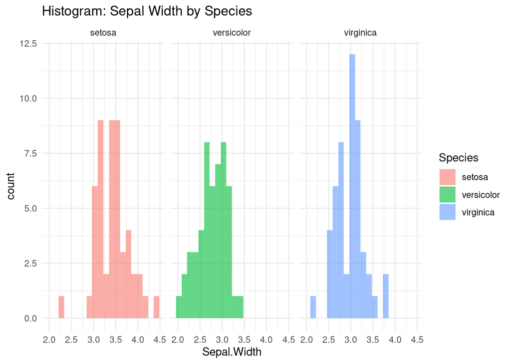

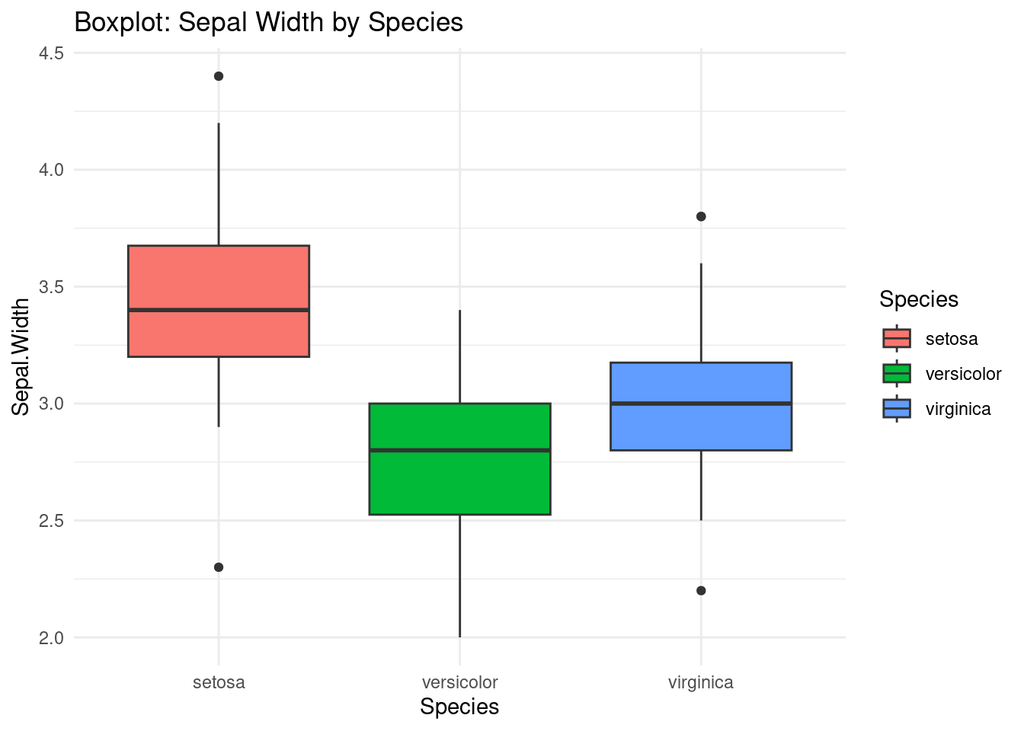

```r
# Histogram and Box plot for Sepal Width
  ggplot(iris, aes(x = Sepal.Width, fill = Species)) +
  geom_histogram(alpha = 0.6, position = "identity", bins = 20) +
  facet_wrap(~ Species) +
  theme_minimal() +
  ggtitle("Histogram: Sepal Width by Species")

  ggplot(iris, aes(x = Species, y = Sepal.Width, fill = Species)) +
  geom_boxplot() +
  theme_minimal() +
  ggtitle("Boxplot: Sepal Width by Species")
```

**Findings**  
*The species setosa tends to have the widest sepals, with most values clustered around 3.5 cm, as shown by both the histogram and the box plot. In contrast, versicolor and virginica have narrower sepals, with versicolor displaying a smaller range of values centered around 2.8 cm and virginica around 3.0 cm.*